# Bayesian Analysis of GHG Fluxes in Seasonal Wetlands

## 6. Model 3 — CH₄ Flux Drivers

```r
mod_ch4_path <- "Data/mod_ch4.rds"

if (file.exists(mod_ch4_path)) {
  mod_ch4 <- readRDS(mod_ch4_path)
} else {
  mod_ch4 <- brm(
    log_fch4 ~ swc_s + ts_s + hand_s + (1 | area) + (1 | point2) + (1 | month),
    data    = df_an,
    family  = gaussian(),
    prior   = prior_flux,
    iter    = 4000,
    warmup  = 1000,
    chains  = 4,
    cores   = 4,
    seed    = 42,
    control = list(adapt_delta = 0.95)
  )
  saveRDS(mod_ch4, mod_ch4_path)
}
```

```r
summary(mod_ch4)
```

```
##  Family: gaussian
##   Links: mu = identity; sigma = identity
## Formula: log_fch4 ~ swc_s + ts_s + hand_s + (1 | area) + (1 | point2) + (1 | month)
##    Data: df_an (Number of observations: 228)
##   Draws: 4 chains, each with iter = 4000; warmup = 1000; thin = 1;
##          total post-warmup draws = 12000
##
## Multilevel Hyperparameters:
## ~area (Number of levels: 5)
##               Estimate Est.Error l-95% CI u-95% CI Rhat Bulk_ESS Tail_ESS
## sd(Intercept)     0.04      0.04     0.00     0.14 1.00     5107     5887
##
## ~month (Number of levels: 6)
##               Estimate Est.Error l-95% CI u-95% CI Rhat Bulk_ESS Tail_ESS
## sd(Intercept)     0.15      0.08     0.06     0.36 1.00     3399     4640
##
## ~point2 (Number of levels: 46)
##               Estimate Est.Error l-95% CI u-95% CI Rhat Bulk_ESS Tail_ESS
## sd(Intercept)     0.05      0.03     0.00     0.11 1.00     2968     4892
##
## Regression Coefficients:
##           Estimate Est.Error l-95% CI u-95% CI Rhat Bulk_ESS Tail_ESS
## Intercept     1.61      0.08     1.46     1.76 1.00     3457     3788
## swc_s         0.10      0.03     0.04     0.16 1.00     6778     7858
## ts_s          0.01      0.03    -0.05     0.06 1.00    10349     9222
## hand_s        0.01      0.02    -0.04     0.05 1.00     7528     8402
##
## Further Distributional Parameters:
##       Estimate Est.Error l-95% CI u-95% CI Rhat Bulk_ESS Tail_ESS
## sigma     0.25      0.01     0.23     0.28 1.00     9387     8675
##
## Draws were sampled using sampling(NUTS). For each parameter, Bulk_ESS
## and Tail_ESS are effective sample size measures, and Rhat is the potential
## scale reduction factor on split chains (at convergence, Rhat = 1).
```

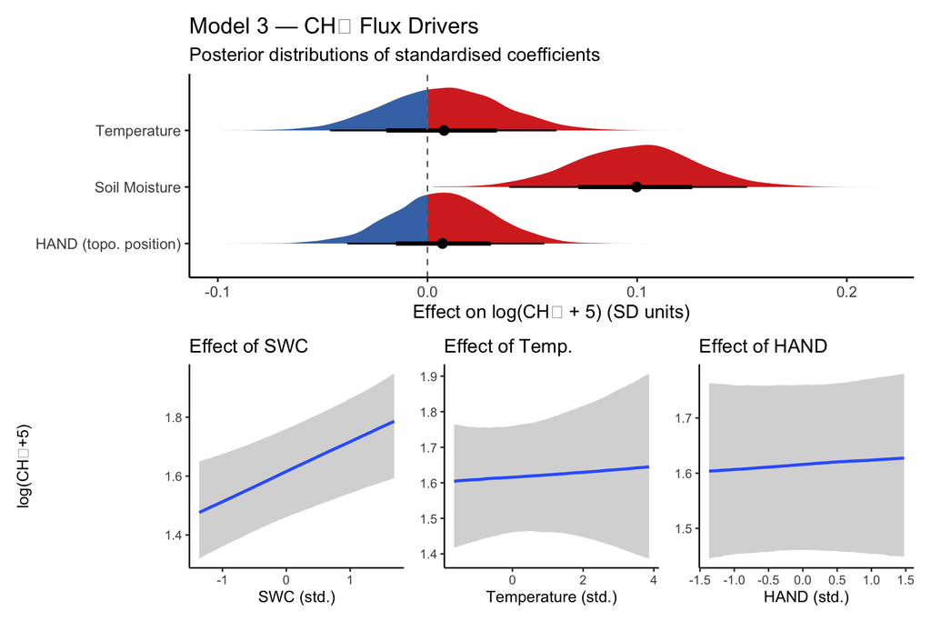

```r
post_ch4 <- as_draws_df(mod_ch4) %>%
  select(starts_with("b_")) %>%
  pivot_longer(everything(), names_to = "parameter", values_to = "value") %>%
  filter(parameter != "b_Intercept") %>%
  mutate(parameter = recode(parameter,
    "b_swc_s"  = "Soil Moisture",
    "b_ts_s"   = "Temperature",
    "b_hand_s" = "HAND (topo. position)"
  ))

p_ch4_coef <- ggplot(post_ch4, aes(x = value, y = parameter, fill = after_stat(x > 0))) +
  stat_halfeye(.width = c(0.66, 0.95), point_interval = median_hdi) +
  geom_vline(xintercept = 0, linetype = "dashed", colour = "grey40") +
  scale_fill_manual(values = c("#4575b4","#d73027"), guide = "none") +
  labs(title    = "Model 3 — CH₄ Flux Drivers",
       subtitle = "Posterior distributions of standardised coefficients",
       x = "Effect on log(CH₄ + 5) (SD units)", y = NULL) +
  theme_classic(base_size = 13)

ce_ch4 <- conditional_effects(mod_ch4,
                               effects    = c("swc_s","ts_s","hand_s"),
                               re_formula = NA)

p_swc3  <- plot(ce_ch4, plot = FALSE)[[1]] +
  labs(x = "SWC (std.)", y = "log(CH₄+5)", title = "Effect of SWC") + theme_classic()
p_ts3   <- plot(ce_ch4, plot = FALSE)[[2]] +
  labs(x = "Temperature (std.)", y = NULL, title = "Effect of Temp.") + theme_classic()
p_hand3 <- plot(ce_ch4, plot = FALSE)[[3]] +
  labs(x = "HAND (std.)", y = NULL, title = "Effect of HAND") + theme_classic()

p_ch4_coef / (p_swc3 + p_ts3 + p_hand3)
```

```r
ggsave("Plots/Bayes_M3_CH4_linear.pdf", width = 10, height = 8)
```

## 6b. Non-linear CH₄ ~ SWC relationship *(NEW)*

> **Motivation:** Unlike CO₂ (which peaks at intermediate moisture via aerobic decomposition), CH₄ production is driven by **methanogenesis** — a strictly anaerobic process. The expected pattern is therefore different:
> - At **low moisture** (aerobic soils): methanogenesis is suppressed, CH₄ ≈ 0 or even negative (net uptake).
> - Above a **saturation threshold**: anaerobic pockets form and CH₄ rises, potentially steeply.
> - At **very high moisture**: production may plateau or continue rising.

> This could look like a monotonic increase, a hockey-stick threshold, or a positively-skewed curve — all quite different from the CO₂ inverted-U. We first look at the raw data, then let a quadratic and a spline model compete to capture whatever shape is actually there.

### Raw data check — GAM smooth by area *(NEW)*

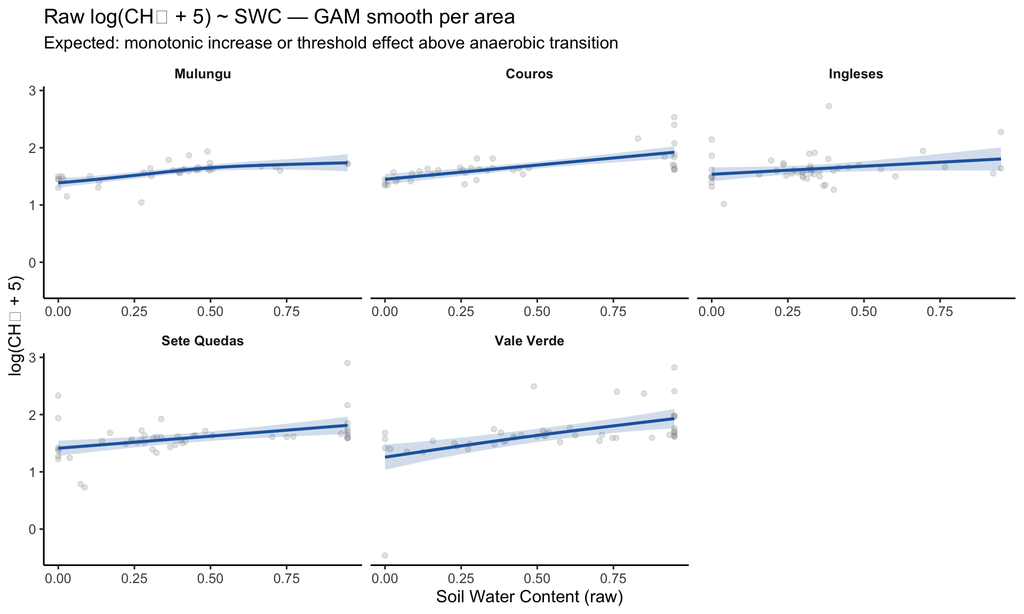

```r
# ── NEW: visualise the raw CH₄ ~ SWC shape before modelling ───────────────────
# fch4 is already shifted by +5 to handle near-zero/negative values.
# Note: unlike CO₂ we expect a positive, possibly accelerating, relationship.
ggplot(df_an, aes(x = swc, y = log_fch4)) +
  geom_point(alpha = 0.25, colour = "grey60", size = 1.5) +
  geom_smooth(method = "gam", formula = y ~ s(x, k = 5),
              colour = "#2166ac", fill = "#2166ac", alpha = 0.2, linewidth = 1) +
  facet_wrap(~area, scales = "free_x",
             labeller = as_labeller(c(vvt   = "Vale Verde",
                                      bbt   = "Mulungu",
                                      cr    = "Couros",
                                      ing   = "Ingleses",
                                      seteq = "Sete Quedas"))) +
  labs(title    = "Raw log(CH₄ + 5) ~ SWC — GAM smooth per area",
       subtitle = "Expected: monotonic increase or threshold effect above anaerobic transition",
       x = "Soil Water Content (raw)", y = "log(CH₄ + 5)") +
  theme_classic(base_size = 12) +
  theme(strip.background = element_blank(),
        strip.text = element_text(face = "bold"))
```

```r
ggsave("Plots/Bayes_CH4_GAM_check.pdf", width = 10, height = 6)
```

### Model 3b — quadratic CH₄ model *(NEW)*

**Formula:** `log(fch4+5) ~ swc + swc² + ts + hand + (1|area) + (1|point2) + (1|month)`

For CH₄ a quadratic can capture either a monotonic acceleration (positive linear + positive quadratic) or a plateau / slight optimum (positive linear + negative quadratic). The sign and magnitude of `swc²` will tell us which pattern fits.

```r
# ── NEW: quadratic CH₄ model ───────────────────────────────────────────────────
mod_ch4_quad_path <- "Data/mod_ch4_quad.rds"

if (file.exists(mod_ch4_quad_path)) {
  mod_ch4_quad <- readRDS(mod_ch4_quad_path)
} else {
  mod_ch4_quad <- brm(
    log_fch4 ~ swc_s + I(swc_s^2) + ts_s + hand_s +
               (1 | area) + (1 | point2) + (1 | month),
    data    = df_an,
    family  = gaussian(),
    prior   = prior_flux,
    iter    = 4000,
    warmup  = 1000,
    chains  = 4,
    cores   = 4,
    seed    = 42,
    control = list(adapt_delta = 0.95)
  )
  saveRDS(mod_ch4_quad, mod_ch4_quad_path)
}
```

### Model 3c — spline CH₄ model *(NEW)*

**Formula:** `log(fch4+5) ~ s(swc_s) + ts + hand + (1|area) + (1|point2) + (1|month)`

A thin-plate spline on SWC (via `brms` + `mgcv`) makes no assumption about the shape — it will find whatever functional form the data support. If it agrees with the quadratic, we have convergent evidence. If the spline looks very different, the relationship is more complex than a simple parabola.

```r
# ── NEW: spline CH₄ model via brms (uses mgcv smooth) ─────────────────────────
mod_ch4_spl_path <- "Data/mod_ch4_spline.rds"

if (file.exists(mod_ch4_spl_path)) {
  mod_ch4_spl <- readRDS(mod_ch4_spl_path)
} else {
  mod_ch4_spl <- brm(
    log_fch4 ~ s(swc_s, k = 5) + ts_s + hand_s +
               (1 | area) + (1 | point2) + (1 | month),
    data    = df_an,
    family  = gaussian(),
    prior   = c(prior(normal(0, 1),   class = "b"),
                prior(normal(0, 2),   class = "Intercept"),
                prior(exponential(1), class = "sd"),
                prior(exponential(1), class = "sigma"),
                prior(exponential(1), class = "sds")),  # prior on spline wiggliness
    iter    = 4000,
    warmup  = 1000,
    chains  = 4,
    cores   = 4,
    seed    = 42,
    control = list(adapt_delta = 0.97)  # splines need slightly higher delta
  )
  saveRDS(mod_ch4_spl, mod_ch4_spl_path)
}
```

### Posterior coefficient plots *(NEW)*

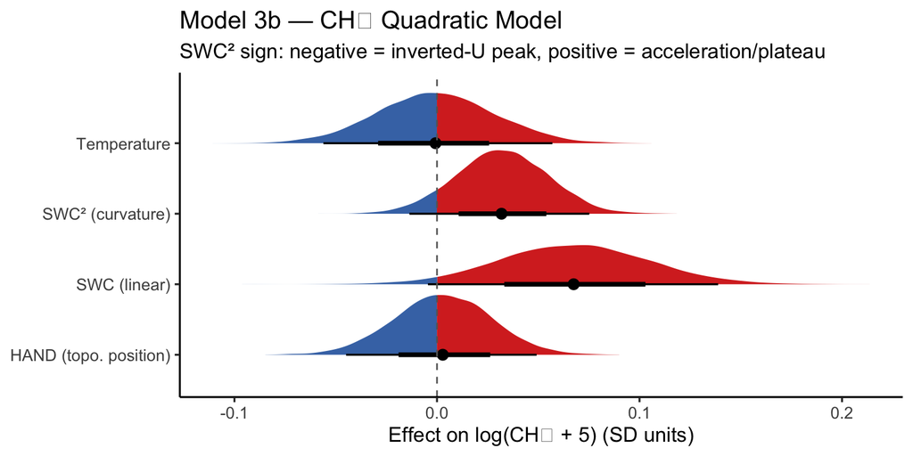

```r
# ── NEW: posteriors for the quadratic CH₄ model ────────────────────────────────
post_ch4_quad <- as_draws_df(mod_ch4_quad) %>%
  select(starts_with("b_")) %>%
  pivot_longer(everything(), names_to = "parameter", values_to = "value") %>%
  filter(parameter != "b_Intercept") %>%
  mutate(parameter = recode(parameter,
    "b_swc_s"    = "SWC (linear)",
    "b_Iswc_sE2" = "SWC² (curvature)",
    "b_ts_s"     = "Temperature",
    "b_hand_s"   = "HAND (topo. position)"
  ))

ggplot(post_ch4_quad,
       aes(x = value, y = parameter, fill = after_stat(x > 0))) +
  stat_halfeye(.width = c(0.66, 0.95), point_interval = median_hdi) +
  geom_vline(xintercept = 0, linetype = "dashed", colour = "grey40") +
  scale_fill_manual(values = c("#4575b4","#d73027"), guide = "none") +
  labs(title    = "Model 3b — CH₄ Quadratic Model",
       subtitle = "SWC² sign: negative = inverted-U peak, positive = acceleration/plateau",
       x = "Effect on log(CH₄ + 5) (SD units)", y = NULL) +
  theme_classic(base_size = 13)
```

```r
ggsave("Plots/Bayes_M3b_CH4_quad_coef.pdf", width = 8, height = 4)
```

### Fitted curves — quadratic vs. spline overlay *(NEW)*

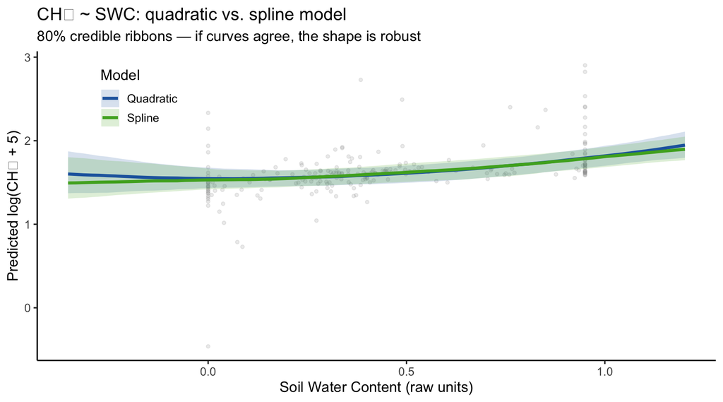

```r
# ── NEW: predict from both models and overlay for comparison ───────────────────
swc_seq <- seq(-2.5, 2.5, length.out = 80)

new_data_ch4 <- expand_grid(
  swc_s  = swc_seq,
  ts_s   = 0,
  hand_s = 0,
  area   = unique(df_an$area)[1],
  point2 = unique(df_an$point2)[1],
  month  = unique(df_an$month)[1]
)

# predictions from quadratic model
pred_ch4_quad <- new_data_ch4 %>%
  add_epred_draws(mod_ch4_quad, ndraws = 500, re_formula = NA) %>%
  group_by(swc_s) %>%
  summarise(med = median(.epred),
            lo  = quantile(.epred, 0.10),
            hi  = quantile(.epred, 0.90),
            .groups = "drop") %>%
  mutate(model = "Quadratic", swc_raw = swc_s * swc_sd + swc_mean)

# predictions from spline model
pred_ch4_spl <- new_data_ch4 %>%
  add_epred_draws(mod_ch4_spl, ndraws = 500, re_formula = NA) %>%
  group_by(swc_s) %>%
  summarise(med = median(.epred),
            lo  = quantile(.epred, 0.10),
            hi  = quantile(.epred, 0.90),
            .groups = "drop") %>%
  mutate(model = "Spline", swc_raw = swc_s * swc_sd + swc_mean)

pred_ch4_both <- bind_rows(pred_ch4_quad, pred_ch4_spl)

ggplot(pred_ch4_both, aes(x = swc_raw, colour = model, fill = model)) +
  # raw data in background
  geom_point(data = df_an, aes(x = swc, y = log_fch4),
             alpha = 0.18, colour = "grey60", size = 1.2, inherit.aes = FALSE) +
  # credible ribbons
  geom_ribbon(aes(ymin = lo, ymax = hi), alpha = 0.18, colour = NA) +
  # fitted lines
  geom_line(aes(y = med), linewidth = 1.3) +
  scale_colour_manual(values = c("Quadratic" = "#2166ac", "Spline" = "#4dac26")) +
  scale_fill_manual(  values = c("Quadratic" = "#2166ac", "Spline" = "#4dac26")) +
  labs(title    = "CH₄ ~ SWC: quadratic vs. spline model",
       subtitle = "80% credible ribbons — if curves agree, the shape is robust",
       x        = "Soil Water Content (raw units)",
       y        = "Predicted log(CH₄ + 5)",
       colour   = "Model", fill = "Model") +
  theme_classic(base_size = 13) +
  theme(legend.position = c(0.15, 0.85))
```

```r
ggsave("Plots/Bayes_M3_CH4_curves_comparison.pdf", width = 9, height = 5)
```